# Analysis of Atmospheric CO2 levels

CO2 in R refers to a dataset of atmospheric CO2 levels recorded by the Mauna Loa Facility. Using the co2 data set built into R we can produce a plot of the CO2 levels recorded beginning in 1959. These CO2 levels were recorded monthly and the data set continues until 1998. This project attempts to determine future estimates for the CO2 levels in the atmosphere that we might see today and also explain the reasoning behind some patterns we see in the data specifically the seasonal changes that we might see.

Using the following R code we can produce the plot to visualise the recorded levels.

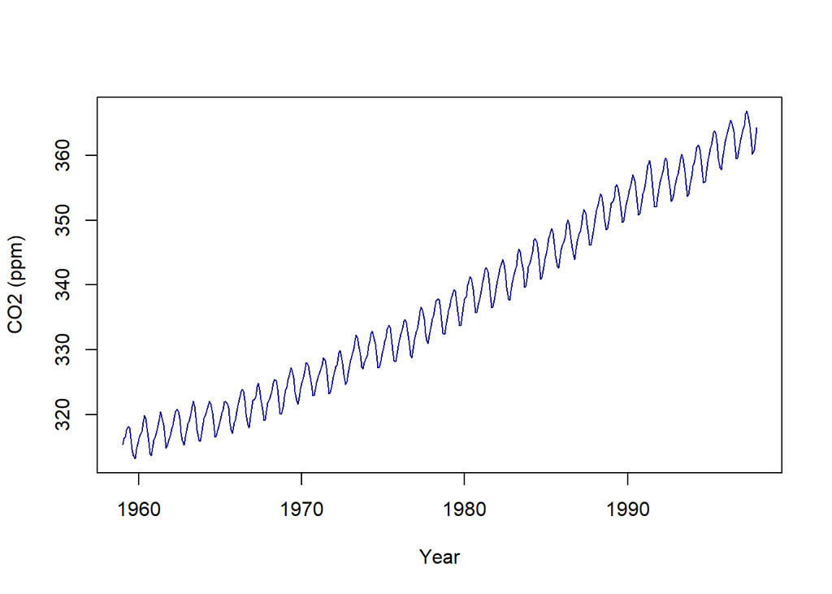

```r
library(prophet)
library(zoo)
data(co2)

Atmospheric_CO2 <- data.frame(
    ds = as.Date(as.yearmon(time(co2))),
    y = as.numeric(co2)
)
# Formatting the plot to look nicer!
plot(Atmospheric_CO2$ds, Atmospheric_CO2$y, type = "l",
     col = "darkblue",
     xlab = "Year",
     ylab = "CO2 (ppm)")
```

At first glance of this, we can see that there is a clear upward trend of CO2 levels and a reoccurring pattern that NASA describes as a “sawtooth” pattern. However, just viewing the recorded data is not of too much interest; let’s take a look at a future prediction.

## 1.1 Predicting ahead!

By using Meta’s Prophet Forecast system we can “look into the future” with our plot. Now where do we see ourselves in 5 years time? Since the data set only reaches 1998 that means we will be looking upto 2003 and can do this with the following code.

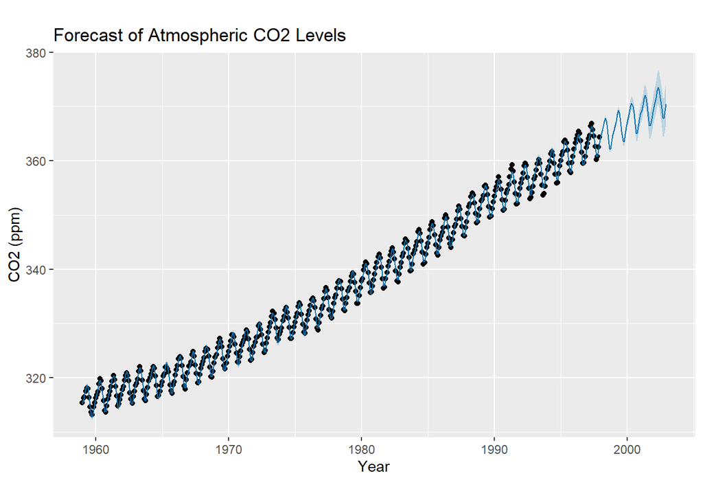

```r
library(ggplot2)
# needed ggplot to format prophet.
library(prophet)
library(zoo)
data(co2)

co2_prediction <- data.frame(
    ds = as.Date(as.yearmon(time(co2))),
    y = as.numeric(co2)
)

pco2_prediction <- prophet(co2_prediction)
# Some issues here with Prophet using days instead of months.
#The value 60 here is how many data points we would like to add

fco2_prediction = make_future_dataframe(pco2_prediction,60, freq = "month")

plottedco2_prediction <-  predict(pco2_prediction,fco2_prediction)
# formatting again
plot(pco2_prediction, plottedco2_prediction) +
  labs(
    x = "Year",
    y = "CO2 (ppm)",
    title = "Forecast of Atmospheric CO2 Levels"
  )
```

Now we have an estimate for future levels of CO2. Looking at the plot we can see both a prediction line and a shaded area. The line suggests the best guess for CO2 levels while the shaded area provides an 80% uncertainty interval which is the range in which future data will likely be.

An 80% uncertainty interval although good is not usually best practice since most scientific standards are at least 95% if not more. So let’s produce a plot with a more accepting interval and by adjusting a single line we can change this.

```r
pco2_prediction <- prophet(co2_prediction, interval.width = 0.95)
```

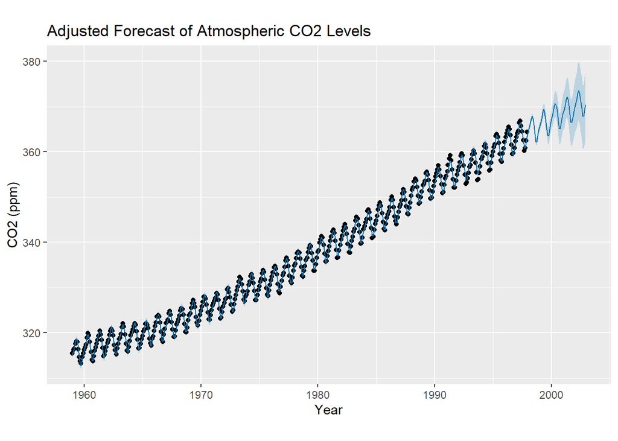

This gives us a more believable future that will be much more likely to fit data points recorded in the future. But how about looking at a prediction of today’s date and comparing it to the most recently recorded CO2 levels in the atmosphere.

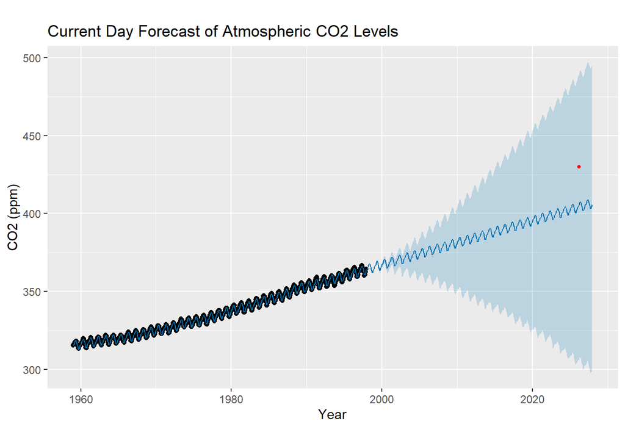

This plot shows us the current day estimates and also a red dot that shows the actual observed data from today’s date. As we can see the recorded data has overshot our estimate for the mean in the future suggesting the rate of CO2 levels increase has grown since our recorded data.

With this being said, it is now time to look more in depth in the patterns of the dataset especially the “sawtooth” pattern noted before.

## 1.2 A Close Up!

Since we are going to zoom in on the data, it is imperative we choose good points data to inspect and so for this we will not be choosing the forecasted data generated previously but instead the latest of the recorded data set. This will be the last 5 years from 1992 to 1998 .

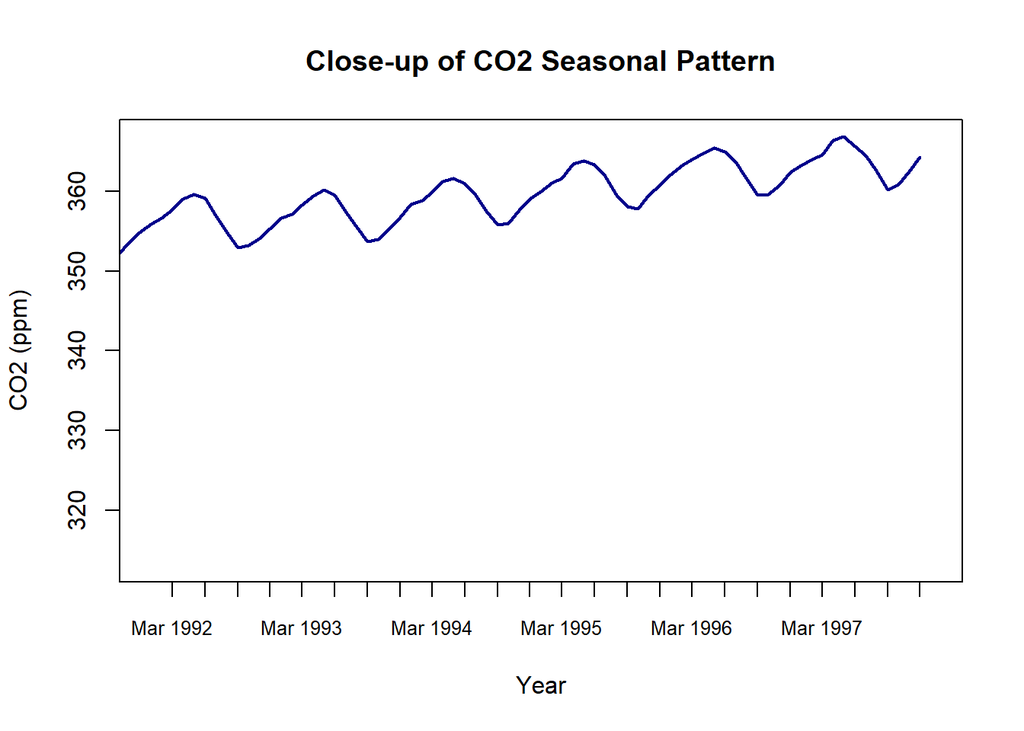

```r
library(prophet)
library(zoo)
data(co2)

Atmospheric_CO2 <- data.frame(
    ds = as.Date(as.yearmon(time(co2))),
    y = as.numeric(co2)
)

plot(Atmospheric_CO2$ds, Atmospheric_CO2$y, type = "l",
     #formatting the plot
     col = "darkblue",
     lwd = 2,
     xlim = as.Date(c("1992-01-01", "1998-01-01")),
     xaxt = "n",   # removes default axis apparently?
     main = "Close-up of CO2 Seasonal Pattern",
     xlab = "Year",
     ylab = "CO2 (ppm)")
#couldnt figure out how to centre this plot
#this gives every 3 months so that we can see the months in which peaks/troughs
#occur.
axis.Date(1,
          at = seq(as.Date("1992-03-01"), as.Date("1998-01-01"), by = "3 months"),
          format = "%b %Y",
          cex.axis = 0.8)
```

Here we can much more visibly see the repeating sawtooth pattern. It seems as though atmospheric CO2 levels peak from the trend in around April or May. On the opposite end of this, troughs from the trend occurs in October. With this plot there is not much to infer past this however, by using Prophet we can look at this in more depth.

Prophet uses a specific model to predict and plot models specifically being:
$$y(t) = g(t) + s(t) +h(t) + \varepsilon_t$$
where
$$y(t)$$
is the forecasted value of y at time = t:
$$g(t)$$
is the trend:
$$s(t)$$
is the seasonality variable:
$$h(t)$$
is a variable determining irregularities and
$$\varepsilon_t$$
is the error term representing noise. Seasonality is of particular interest and we can find that Prophet uses the Fourier series to determine this which is:
$$s(t) = \sum_{n=1}^N (a_ncos(\frac{(2\pi nt)}{P} )+ b_nsin(\frac{2\pi
nt}{P}))$$
By running the following code we can plot the components that Prophet uses. Since we have no input for h(t) and the error term is merely representing noise we will only be looking at the trend value and seasonality.

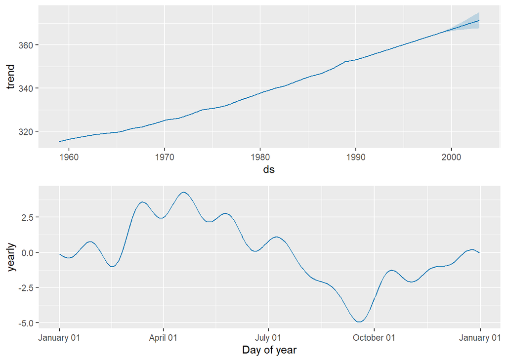

```r
prophet_trendplot <- prophet(Atmospheric_CO2)
predictedplot <- make_future_dataframe(prophet_trendplot,60,freq = "month")
prophet_seasonalityplot <- predict(prophet_trendplot,predictedplot)
prophet_plot_components(prophet_trendplot,prophet_seasonalityplot)
```

## 1.3 Exploring the Seasonality!

A simple perspective of this plot would lead you to recognise that CO2 levels begin to climb towards and above the trend during the autumn season and sink down and past the trend around the beginning of summer. Given that the primary reason for CO2 level changes is due to plants, trees and greenery absorbing CO2 from the atmosphere, we can fairly assume that since during summer all plants are in bloom that it makes sense for CO2 levels to decline again up until the point where most plants either die or are dormant. Through basic reasoning we can determine that this point in which the greenery dies must be just before October as this is the point wherein CO2 levels begin to climb again.

This would be a good assumption for us to start with; however, this assumes that season times are universal which is not fact. The seasons in the northern hemisphere are directly opposite to those of the southern hemisphere therefore we must deduce that there is an imbalance of plants and greenery between the northern and southern hemisphere specifically being that the northern hemisphere’s CO2 absorption overwhelms the southern hemisphere’s. Let’s take a look at a map of the existing greenery.

[figure not shown]

Since the equator does not experience the typical high and low temperature seasons; there is no reason to include them in the theory as greenery in the middle third region of the world often does not go dormant leading to constant CO2 absorption year round! Now comparing the top third of the map to the bottom third we can see a clear overwhelming majority of the greenery lies in the northern hemisphere. This would confirm our suspicions that the northern hemisphere on average absorbs more CO2. There are of course other factors to consider such as ocean life being a very strong contributor to CO2 absorption but since the southern hemisphere is largely deep ocean there is very little reason to accept this as a factor.

## 1.4 A summary of impending doom.

Concluding from our data and analysis we can see a clear steady increase of CO2 levels in the atmosphere from 1959 to 1998 however, an inclusion of the most recently recorded data shows that although the current CO2 levels are within our 95% uncertainty interval; they have overshot our estimated mean suggesting an increase in the rate of increase of CO2 levels in the atmosphere. It is imperative to understand here that there is a very strong correlation between Atmospheric CO2 levels and Global Temperature see below:

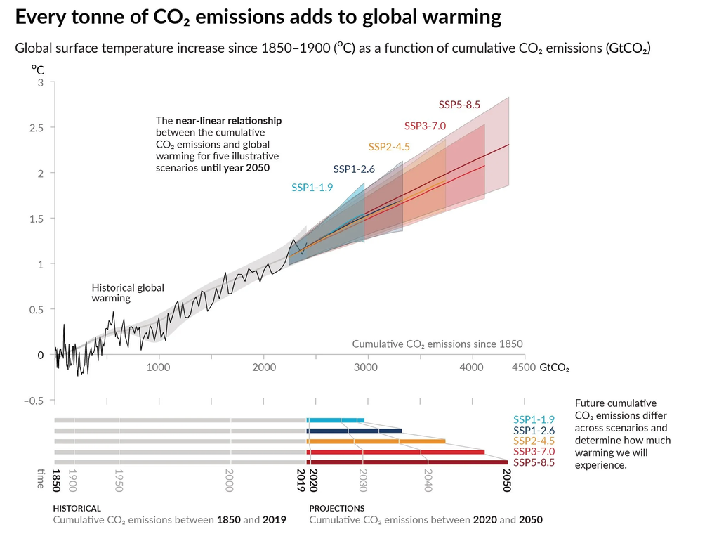

Since the trend has increased it is critical we remain wary of the issues that arise from global temperature increase as it will directly affect our future. A decrease to our CO2 emissions is needed if we would like to avoid catastrophe. With this my analysis is complete, thank you for reading!

# References

- Datacamp course: https://www.datacamp.com/courses/reporting-with-rmarkdown
- RStudio reference: https://rmarkdown.rstudio.com/lesson-1.html
- More sophisticated reference: https://bookdown.org/yihui/rmarkdown/
- NASA sawtooth pattern https://science.nasa.gov/earth/natural-disasters/volcanoes/how-do-we-know-mauna-loa-carbon-dioxide-measurements-dont-include-volcanic-gases/
- Shaded area https://www.linkedin.com/pulse/d365-demand-planning-deep-dive-part-9-prophet-model-el-bardisy-stv8f/
- Latex https://tex.stackexchange.com/questions/1368/why-can-i-only-use-some-capital-greek-letters-inside-my-equations
- Latex https://www.overleaf.com/learn/latex/Fractions_and_Binomials
- Latex https://www.overleaf.com/learn/latex/Integrals%2C_sums_and_limits#Sums_and_products
- Seasonality Formula https://medium.com/@ipeksahbazoglu/facebooks-prophet-a-humble-user-guide-c1a42b16582c
- CO2 levels https://www.co2.earth/daily-co2
- Using ggplot2 https://ggplot2.tidyverse.org/articles/ggplot2.html
- CO2 Temp relation https://www.environmentalgraphiti.org/all-series/emissions-levels-determine-temperature-rise